# Transferring Projectiles Between Viewports

Although we get targeting information from the opponents ship, we have yet to use it.

In a previous lesson, we saw how to remove a *Projectile* from the scene once it travels a certain distance.

In this lesson, we’ll take that idea further and implement *Projectile* transfer between viewports so that the two ships can interact with each other.

## Updating the projectile script

The strategy for transferring the *Projectile* from one viewport to the other is:

1. Remove the *Projectile* node after traveling a given distance.
2. Emit a signal carrying a payload when the *Projectile* gets removed from the scene.
3. Respawn the *Projectile* in the other viewport and update its properties to match the payload from the signal.

After setting the matching parameters on the new *Projectile*, we’re in a fire-and-forget situation. Godot can take care of the *Projectile* management for us.

Now, there are a few changes we have to make to implement the steps above. Open `res://TacticalSpaceCombat/Ship/Weapons/Projectile.gd` and since the following code is short, it’s easier to replace everything with:

```
class_name Projectile
extends RigidBody2D

const MAX_DISTANCE := 2000

## We switch to using a variable to check traveled distance to set it from other
## scripts.
var max_distance := MAX_DISTANCE

## Save the position at which we spawn the `Projectile` to calculate the
## distance traveled.
var _origin := Vector2.ZERO


func _ready() -> void:
    _origin = position


func _process(delta: float) -> void:
    if position.distance_to(_origin) > max_distance:
        queue_free()
```

## Updating the projectile weapon script

We now update the projectile weapon script to emit a signal when the projectile exits the scene tree.

With this signal, we transfer information to update the new *Projectile* node properties.

Open `res://TacticalSpaceCombat/Ship/Weapons/WeaponProjectile.gd` and add the following signal at the top:

```
signal projectile_exited(params)
```

Now we need to update `fire()`:

```
func fire() -> void:
    # ...
    # projectile.linear_velocity =
    # projectile.linear_velocity.rotated(global_rotation)
    var params := {"physics_layer": _physics_layer, "target_position": target_position}
    projectile.connect("tree_exited", self, "emit_signal", ["projectile_exited", params])
    # ...
```

We connect the `tree_exited` signal from the *Projectile* node so that it emits our custom `projectile_exited` signal. This way, we can carry the params over to the new projectile.

## Updating the utils script

We need a position from which to spawn the projectile into the other viewport. We want a far-away place from the opponent ship.

To pick a location like this, we’ll add a utility function that generates a random value on a circle of a given radius. Open `res://TacticalSpaceCombat/Utils.gd` and add this function:

```
## Returns a random `Vector2` on a circle of the given `radius` by picking a
## random angle.
static func randvf_circle(_rng: RandomNumberGenerator, radius: float) -> Vector2:
    # `TAU` is a built in constant equal with `2 * PI` - a full circle.
    return (radius * Vector2.RIGHT).rotated(_rng.randf_range(0, TAU))
```

## Updating the ship

We need a place in our scene tree to add the incoming projectiles from the opponent ship.

But first, let’s add a property to the *Rooms* script that holds the mean position of the rooms. Since we can place the rooms in any way relative to the ship’s origin, it’s helpful to find the ships center as a reference point.

Open the `res://TacticalSpaceCombat/Ship/Rooms.gd` script and add the following variable at the top:

```
var mean_position := Vector2.INF
```

We’ll calculate it at run-time in the `_ready()` function:

```
func _ready() -> void:
    # ...
    mean_position = _get_mean_position()
```

Now let’s complete the update by adding the function to get the mean position:

```
func _get_mean_position() -> Vector2:
    var out := Vector2.ZERO
    for room in get_children():
        out += room.position

    if _rooms_count > 0:
        out /= _rooms_count
    return out
```

### Adding the projectiles group node

As mentioned above, we need a place in the scene tree for the incoming projectiles from the other ship. We need a new group node to manage these.

Open the *ShipTemplate* scene and add a

[figure not shown]

`Node2D` to the tree. Name it *Projectiles*:

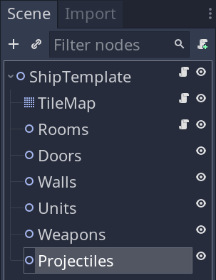

Add a script to the newly created *Projectiles* node with the following content:

```
extends Node2D

const Projectile = preload("Weapons/Projectile.tscn")

var _rng := RandomNumberGenerator.new()
var _mean_position := Vector2.INF


func setup(mean_position: Vector2) -> void:
    _mean_position = mean_position


func _ready() -> void:
    _rng.randomize()


func _on_Weapon_projectile_exited(params: Dictionary) -> void:
    var projectile: RigidBody2D = Projectile.instance()
    # The spawn position is on a circle of radius `projectile.MAX_DISTANCE`,
    # centered at `_mean_position`.
    var spawn_position := _mean_position + Utils.randvf_circle(_rng, projectile.MAX_DISTANCE)

    # Remember that we request new `target_position` from the `Controller`
    # scripts. We get it from the `projectile_exited` payload and use it to
    # calculate the Projectile's direction.
    var direction: Vector2 = (params.target_position - spawn_position).normalized()

    # We calculate matching properties based on `direction`. Once these are set,
    # the `RigidBody2D` node takes care of the motion.
    projectile.position = spawn_position
    projectile.linear_velocity = direction * projectile.linear_velocity.length()
    projectile.rotation = direction.angle()

    # We also update the `collision_layer` so that it interacts with the correct
    # ship.
    projectile.collision_layer = params.physics_layer

    # We double the `max_distance` parameter so that the `Projectile` has enough
    # room to travel outside the screen before it gets removed.
    projectile.max_distance *= 2

    add_child(projectile)
```

We still need to update the *ShipTemplate* script to reference the new *Projectiles* node and initiate its setup. To do that, let’s open `res://TacticalSpaceCombat/Ship/ShipTemplate.gd` and add the reference to *Projectiles*:

```
onready var projectiles: Node2D = $Projectiles
```

To finish up the setup, add the following line at the end of `_ready_not_editor_hint()`:

```
func _ready_not_editor_hint() -> void:
    # ...
    projectiles.setup(rooms.mean_position)
```

We have one last missing link - connecting the signals. We do this in the `res://TacticalSpaceCombat.gd` script. Open it and add the following code to the `_ready_weapons_ai()` function:

```
func _ready_weapons_ai() -> void:
    # ...
            # controller.connect("targeting", ship_player.rooms,
            # "_on_Controller_targeting")
            controller.weapon.connect(
                "projectile_exited", ship_player.projectiles, "_on_Weapon_projectile_exited"
            )
    # ...
```

## Conclusion

We made a lot of small changes to transfer the *Projectile* nodes from one viewport to the other.

With these updates, you should get something like this:

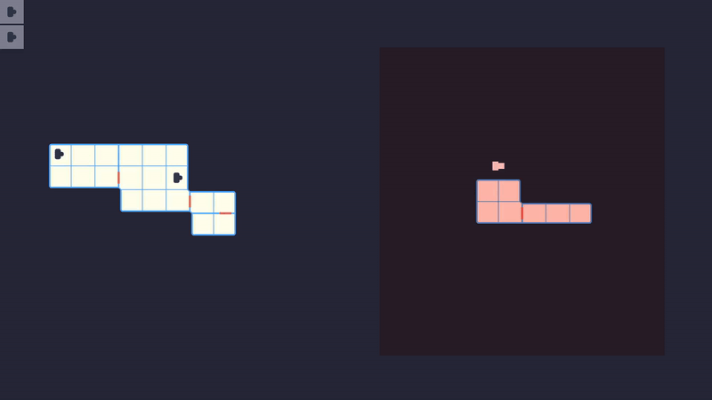

*Note* that I tinted the AI ship viewport to distinguish it easier.

If you now play the game, the *Projectile* nodes should transfer information from one viewport to the other and travel towards randomly picked rooms. This is due to the *Controller* nodes requesting new targets every time the AI fires the projectile weapon.

We saw how to efficiently connect signals from different parts of our systems to manage a scenario in which we require the transfer of information from one node to another to create the illusion of traversing from one isolated part of the game to the other.

For now, the projectiles don’t interact with the opponent rooms. We’ll add this functionality later when we introduce hit points.

## Code reference

`res://TacticalSpaceCombat.gd`:

```
extends Node2D

const UIUnit = preload("TacticalSpaceCombat/UI/UIUnit.tscn")

onready var ship_player: Node2D = $ShipPlayer
onready var ship_ai: Node2D = $ViewportContainer/Viewport/ShipAI
onready var ui_units: VBoxContainer = $UI/Units


func _ready() -> void:
    _ready_units()
    _ready_weapons_ai()


func _ready_units() -> void:
    for unit in ship_player.units.get_children():
        var ui_unit: ColorRect = UIUnit.instance()
        ui_units.add_child(ui_unit)
        unit.setup(ui_unit)


func _ready_weapons_ai() -> void:
    for controller in ship_ai.weapons.get_children():
        if controller is ControllerAIProjectile:
            controller.connect("targeting", ship_player.rooms, "_on_Controller_targeting")
            controller.weapon.connect(
                "projectile_exited", ship_player.projectiles, "_on_Weapon_projectile_exited"
            )
            ship_player.rooms.connect("targeted", controller, "_on_Ship_targeted")
```

`res://TacticalSpaceCombat/Ship/ShipTemplate.gd`:

```
tool
class_name ShipTemplate
extends Node2D

var _slots := {}

onready var scene_tree: SceneTree = get_tree()
onready var tilemap: TileMap = $TileMap
onready var rooms: Node2D = $Rooms
onready var doors: Node2D = $Doors
onready var units: Node2D = $Units
onready var weapons: Node2D = $Weapons
onready var projectiles: Node2D = $Projectiles


func _ready() -> void:
    call("_ready_editor_hint" if Engine.editor_hint else "_ready_not_editor_hint")


func _ready_editor_hint() -> void:
    for room in rooms.get_children():
        room.setup(tilemap)


func _ready_not_editor_hint() -> void:
    for unit in units.get_children():
        for door in doors.get_children():
            door.connect("opened", unit, "set_is_walking", [true])

        var position_map := tilemap.world_to_map(unit.path_follow.position)
        _slots[position_map] = unit

    for room in rooms.get_children():
        room.setup(tilemap)
        for point in room:
            tilemap.set_cellv(point, 0)
    tilemap.setup(rooms, doors)
    projectiles.setup(rooms.mean_position)


func _unhandled_input(event: InputEvent) -> void:
    if not event.is_action_pressed("right_click"):
        return

    for unit in scene_tree.get_nodes_in_group("selected-unit"):
        var point1: Vector2 = tilemap.world_to_map(unit.path_follow.position)
        for room in scene_tree.get_nodes_in_group("selected-room"):
            if not room.owner.is_in_group("player"):
                break

            var point2: Vector2 = room.get_slot(_slots, unit)
            if is_inf(point2.x):
                break

            var path: Curve2D = tilemap.find_path(point1, point2)
            Utils.erase_value(_slots, unit)
            _slots[point2] = unit
            unit.walk(path)
```

`res://TacticalSpaceCombat/Ship/Rooms.gd`:

```
extends Node2D

signal targeted(msg)

var mean_position := Vector2.INF

var _rng := RandomNumberGenerator.new()
var _rooms_count := 0


func _ready() -> void:
    _rng.randomize()
    _rooms_count = get_child_count()
    mean_position = _get_mean_position()


func _on_Controller_targeting(msg: Dictionary) -> void:
    var r := _rng.randi_range(0, _rooms_count - 1)
    var room: Room = get_child(r)
    msg.target_position = room.position
    emit_signal("targeted", msg)


func _get_mean_position() -> Vector2:
    var out := Vector2.ZERO
    for room in get_children():
        out += room.position

    if _rooms_count > 0:
        out /= _rooms_count
    return out
```

`res://TacticalSpaceCombat/Ship/Projectiles.gd`:

```
extends Node2D

const Projectile = preload("Weapons/Projectile.tscn")

var _rng := RandomNumberGenerator.new()
var _mean_position := Vector2.INF


func setup(mean_position: Vector2) -> void:
    _mean_position = mean_position


func _ready() -> void:
    _rng.randomize()


func _on_Weapon_projectile_exited(params: Dictionary) -> void:
    var projectile: RigidBody2D = Projectile.instance()
    var spawn_position := _mean_position + Utils.randvf_circle(_rng, projectile.MAX_DISTANCE)
    var direction: Vector2 = (params.target_position - spawn_position).normalized()
    projectile.collision_layer = params.physics_layer
    projectile.position = spawn_position
    projectile.linear_velocity = direction * projectile.linear_velocity.length()
    projectile.rotation = direction.angle()
    projectile.max_distance *= 2
    add_child(projectile)
```

`res://TacticalSpaceCombat/Ship/Weapons/Projectile.gd`:

```
class_name Projectile
extends RigidBody2D

const MAX_DISTANCE := 2000

var max_distance := MAX_DISTANCE

var _origin := Vector2.ZERO


func _ready() -> void:
    _origin = position


func _process(delta: float) -> void:
    if position.distance_to(_origin) > max_distance:
        queue_free()
```

`res://TacticalSpaceCombat/Ship/Weapons/WeaponProjectile.gd`:

```
tool
extends Weapon

signal fired
signal projectile_exited(params)

const Projectile := preload("Projectile.tscn")

var target_position := Vector2.INF

var _physics_layer := -1


func setup(physics_layer: int) -> void:
    _physics_layer = physics_layer


func _get_configuration_warning() -> String:
    var parent := get_parent()
    var is_verified := parent != null and parent is ControllerAIProjectile
    return "" if is_verified else "WeaponProjectile needs to be a parent of ControllerAIProjectile"


func fire() -> void:
    if not can_fire():
        return

    self.is_charging = true
    var projectile: RigidBody2D = Projectile.instance()
    projectile.linear_velocity = projectile.linear_velocity.rotated(global_rotation)
    var params := {"physics_layer": _physics_layer, "target_position": target_position}
    projectile.connect("tree_exited", self, "emit_signal", ["projectile_exited", params])
    add_child(projectile)
    emit_signal("fired")


func can_fire() -> bool:
    return not is_charging and target_position != Vector2.INF
```

`res://TacticalSpaceCombat/Utils.gd`:

```
class_name Utils

const DIRECTIONS := [
    Vector2.UP,
    Vector2.RIGHT + Vector2.UP,
    Vector2.RIGHT,
    Vector2.RIGHT + Vector2.DOWN,
    Vector2.DOWN,
    Vector2.LEFT + Vector2.DOWN,
    Vector2.LEFT,
    Vector2.LEFT + Vector2.UP
]

static func xy_to_index(width: int, offset: Vector2) -> int:
    return int(offset.x + width * offset.y)

static func index_to_xy(width: int, index: int) -> Vector2:
    return Vector2(index % width, index / width)

static func erase_value(dict: Dictionary, value) -> bool:
    var out := false
    for key in dict:
        if dict[key] == value:
            out = dict.erase(key)
    return out

static func randvf_circle(_rng: RandomNumberGenerator, radius: float) -> Vector2:
    return (radius * Vector2.RIGHT).rotated(_rng.randf_range(0, TAU))
```